# Trees and Forests Assignment

Michalina Jablonska

2020-09-17

## Load the libraries + functions

Load all the libraries or functions that you will use to for the rest of the assignment. It is helpful to define your libraries and functions at the top of a report, so that others can know what they need for the report to compile correctly.

You will be distinguishing between the categories of *nerd* and *geek* to determine the influence of respective variables on their category definition. Semantically, the words are similar but in this exercise you will determine if they are used differently and what the features are that may separate them into different categories.

The data for this project has already been loaded. Drawing from multiple corpora, for each instance where the word *nerd* or *geek* was used, the context surrounding it was coded including whether whether the word was referencing one or multiple people (Num), when it was used (Century, 20th or 21st), the type of corpora (academic, magazines, newspapers, spoken language), and the evaluation of the valence/sentiment of the word (negative, neutral, or positive).

Questions which require a written response are marked with **. If you are having trouble with the `Rling` library - the nerd data is available on Canvas, and you can load it directly.

```r
##r chunk
library(Rling)
library(party)
library(reticulate)
py_config()
```

```
## python:         /usr/bin/python3
## libpython:      /usr/lib/python3.8/config-3.8-x86_64-linux-gnu/libpython3.8.so
## pythonhome:     //usr://usr
## version:        3.8.2 (default, Jul 16 2020, 14:00:26)  [GCC 9.3.0]
## numpy:          /usr/lib/python3/dist-packages/numpy
## numpy_version:  1.17.4
```

```r
py_module_available("sklearn")
```

```
## [1] TRUE
```

```r
data(nerd)
head(nerd)
```

```
##   Noun Num Century Register    Eval
## 1 nerd  pl      XX     ACAD Neutral
## 2 nerd  pl     XXI     ACAD Neutral
## 3 nerd  pl      XX     ACAD Neutral
## 4 nerd  pl      XX     ACAD Neutral
## 5 nerd  pl      XX     ACAD Neutral
## 6 nerd  pl     XXI     ACAD Neutral
```

## Description of the data

Dependent variable:

- Noun: which category is represented either *nerd* or *geek*.

Independent variables:

- Num: a measure of social group, either pl (plural) or sg (single)
- Century: when the word was used, as XX (20th) or XXI (21st) century
- Register: information about the context of the word; coded as ACAD (academic), MAG (magazine), NEWS (newspapers), and SPOK (spoken)
- Eval: A measure of the valence of the word, Neg for negative, Neutral, and Positive

## Conditional inference model

- Add a random number generator to start the model.
- Use `ctree()` to create a conditional inference model.

```r
set.seed(123456)
tree.output = ctree(Noun ~ Num + Century + Register + Eval, data = nerd)
```

## Make a plot

- Plot the conditional inference model.

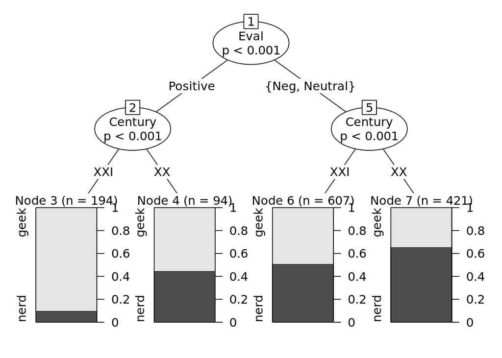

```r
plot(tree.output)
```

## Interpret the categories

- ** Write out an interpretation of the results from the model. You can interpret the branches of the tree to determine what features defines each category.
- With only two categories, you will see the proportion split as the output in the bar graph - look for the group with the larger proportion.

The valence of the word is a significant (p < .001) predictor variable that is most correlated to the word used (“nerd” vs “geek”). We have the best split for valence reflected in two categories: “positive” and “negative/neutral”. The next significant split is by century (20th vs 21st; p < .001). Based on these predictors we observe that:

- for positive valence of the word in 20th century, the usage of both words is pretty even with a somewhat stronger tendency for the word “geek” whereas in 21st century the tendency of using the word “geek” in positive ccontext would be very strong (~90% of the time)
- with negative/neutral valence of the word in the 21st century the split is even; the probability of using the word “nerd” in negative or neutral sentiment was higher for the 20th century

## Conditional inference model predictiveness

- Calculate the percent correct classification for the conditional inference model.

```r
outcomes = table(predict(tree.output), nerd$Noun)
outcomes
```

```
##
##        geek nerd
##   geek  227   61
##   nerd  443  585
```

```r
sum(diag(outcomes)) / sum(outcomes) * 100
```

```
## [1] 61.70213
```

## Random forests

- Create a random forest of the same model for geek versus nerd.

```r
forest.output = cforest(Noun ~ Num + Century + Register + Eval, data = nerd, controls = cforest_unbiased(ntree = 500, mtry = 2))
```

## Variable importance

- Calculate the variable importance from the random forest model.
- Include a dot plot of the importance values.
- ** Which variables were the most important?
- Eval and Century seem to be the most important

```r
forest.importance = varimp(forest.output, conditional = T)
round(forest.importance, 3)
```

```
##      Num  Century Register     Eval
##    0.000    0.025   -0.001    0.055
```

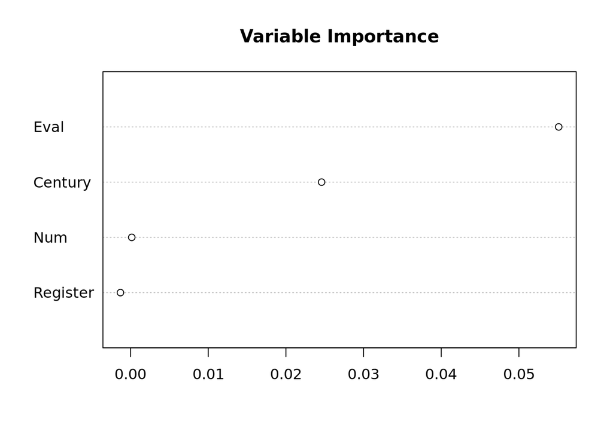

```r
dotchart(sort(forest.importance), main= "Variable Importance")
```

## Forest model predictiveness

- Include the percent correct for the random forest model.
- ** Did it do better than the conditional inference tree?
- Yes, it did slightly better with 63.4% compared to 61.7% of the cases that tree model is predicting

```r
forest.outcomes = table(predict(forest.output), nerd$Noun)
forest.outcomes
```

```
##
##        geek nerd
##   geek  325  136
##   nerd  345  510
```

```r
sum(diag(forest.outcomes)) / sum(forest.outcomes) * 100
```

```
## [1] 63.44985
```

## Python model

- In this section, import the data from R to Python.
- Be sure to convert the categorical data into dummy coded data.

```python
import sklearn
from sklearn import tree
import pandas as pd

Xvars = pd.get_dummies(r.nerd[["Num", "Century", "Register", "Eval"]])
Xvars.head()
```

```
##    Num_pl  Num_sg  Century_XX  ...  Eval_Neg  Eval_Neutral  Eval_Positive
## 0       1       0           1  ...         0             1              0
## 1       1       0           0  ...         0             1              0
## 2       1       0           1  ...         0             1              0
## 3       1       0           1  ...         0             1              0
## 4       1       0           1  ...         0             1              0
##
## [5 rows x 11 columns]
```

```python
Yvar = pd.get_dummies(r.nerd["Noun"])
Yvar.head()
```

```
##    geek  nerd
## 0     0     1
## 1     0     1
## 2     0     1
## 3     0     1
## 4     0     1
```

## Create the Tree

- Create a decision tree classification of the `nerd` data.

```python
CIT = tree.DecisionTreeClassifier()
CIT = CIT.fit(Xvars, Yvar)
```

## Printing out the Tree

- Print out a text version of the classification tree.

```python
print(tree.export_text(CIT, feature_names = list(Xvars.columns)))
```

```
## |--- Eval_Positive <= 0.50
## |   |--- Century_XXI <= 0.50
## |   |   |--- Num_sg <= 0.50
## |   |   |   |--- Register_ACAD <= 0.50
## |   |   |   |   |--- Register_MAG <= 0.50
## |   |   |   |   |   |--- Eval_Neutral <= 0.50
## |   |   |   |   |   |   |--- Register_NEWS <= 0.50
## |   |   |   |   |   |   |   |--- class: 0
## |   |   |   |   |   |   |--- Register_NEWS >  0.50
## |   |   |   |   |   |   |   |--- class: 0
## |   |   |   |   |   |--- Eval_Neutral >  0.50
## |   |   |   |   |   |   |--- Register_SPOK <= 0.50
## |   |   |   |   |   |   |   |--- class: 0
## |   |   |   |   |   |   |--- Register_SPOK >  0.50
## |   |   |   |   |   |   |   |--- class: 0
## |   |   |   |   |--- Register_MAG >  0.50
## |   |   |   |   |   |--- Eval_Neg <= 0.50
## |   |   |   |   |   |   |--- class: 0
## |   |   |   |   |   |--- Eval_Neg >  0.50
## |   |   |   |   |   |   |--- class: 0
## |   |   |   |--- Register_ACAD >  0.50
## |   |   |   |   |--- class: 0
## |   |   |--- Num_sg >  0.50
## |   |   |   |--- Register_ACAD <= 0.50
## |   |   |   |   |--- Register_MAG <= 0.50
## |   |   |   |   |   |--- Register_SPOK <= 0.50
## |   |   |   |   |   |   |--- Eval_Neg <= 0.50
## |   |   |   |   |   |   |   |--- class: 0
## |   |   |   |   |   |   |--- Eval_Neg >  0.50
## |   |   |   |   |   |   |   |--- class: 0
## |   |   |   |   |   |--- Register_SPOK >  0.50
## |   |   |   |   |   |   |--- Eval_Neutral <= 0.50
## |   |   |   |   |   |   |   |--- class: 1
## |   |   |   |   |   |   |--- Eval_Neutral >  0.50
## |   |   |   |   |   |   |   |--- class: 0
## |   |   |   |   |--- Register_MAG >  0.50
## |   |   |   |   |   |--- Eval_Neg <= 0.50
## |   |   |   |   |   |   |--- class: 0
## |   |   |   |   |   |--- Eval_Neg >  0.50
## |   |   |   |   |   |   |--- class: 0
```

[output cut: 78 more lines]

```
## |   |   |   |   |   |   |--- class: 0
## |   |   |   |   |   |--- Register_SPOK >  0.50
## |   |   |   |   |   |   |--- class: 0
## |   |   |   |   |--- Num_pl >  0.50
## |   |   |   |   |   |--- Register_SPOK <= 0.50
## |   |   |   |   |   |   |--- class: 0
## |   |   |   |   |   |--- Register_SPOK >  0.50
## |   |   |   |   |   |   |--- class: 0
## |   |   |   |--- Register_ACAD >  0.50
## |   |   |   |   |--- class: 0
## |   |   |--- Register_MAG >  0.50
## |   |   |   |--- Num_sg <= 0.50
## |   |   |   |   |--- class: 1
## |   |   |   |--- Num_sg >  0.50
## |   |   |   |   |--- class: 1
```

## Confusion Matrix

```python
import numpy as np
Y_predict = pd.DataFrame(CIT.predict(Xvars))
Y_predict.columns = list(Yvar.columns)
Y_predict_category = Y_predict.idxmax(axis=1)
Yvar_category = Yvar.idxmax(axis=1)

cm = sklearn.metrics.confusion_matrix(Y_predict_category, Yvar_category)
print(cm)
```

```
## [[401 207]
##  [269 439]]
```

```python
print((np.trace(cm)/np.sum(cm))*100)
```

```
## 63.829787234042556
```

## Thought questions

- ** Are the models easier to create using R or Python (your own thoughts, they can be different than what I said in the lecture)?
- With the (tiny) experience I had so far with both, the R was easier for me to make sense of plus as a visual learner I liked to have the actual tree easily visualized. I can imagine there may be a possibility to achieve a similar result in Python but R made is pretty easy.
- ** Which model gave you a better classification of the categories?
- Python model has more detailed classification of the categories
- ** What other variables might be useful in understanding the category membership of geek versus nerd? Basically, what could we add to the model to improve it (there’s no one right answer here - it’s helpful to think about what other facets we have not measured)?
- Location could be one to measure though I believe there are some cultural differences to be taken into account (as for example I cannot really think of a good equivalent of ‘nerd’ or ‘geek’ in Polish)
- Length of the sentence that contains the word (in number of characters: less than of more than 40?)?